# R exercise 6: Clustering

Kelsey Gonzalez and Laura Werthmann

October 3, 2019

Due Nov 27

Load packages

```r
library(tidyverse) # for data cleaning and visualization
library(ISLR) # for college dataset
library(cluster) # for gower similarity, pam, and diana (a divisive hierarchical method). clara() is also included, which is basically pam by sampling
library(Rtsne) # for t-SNE plot
```

Clustering requires 1. Calculating distance among the observations 2. Choosing a clustering algorithm 3. Selecting the number of clusters

distance measures for continuous variables: dist() generate a 5x10 matrix with random data

```r
set.seed(2345) #to get repeatable results
randDat <- matrix(rnorm(50), nrow=5)
dist(randDat)
```

```
##          1        2        3        4
## 2 4.031916
## 3 3.779423 4.613105
## 4 2.967834 3.084064 3.110747
## 5 3.495382 4.053591 1.880730 2.832588
```

calculate distances

```r
#Manhattan
dist(randDat, method="manhattan")
```

```
##           1         2         3         4
## 2 10.529280
## 3  9.640908 11.909075
## 4  8.248789  8.180558  8.458840
## 5  9.382806  9.421313  4.349326  7.784916
```

```r
dist(randDat, method="minkowski", p=4)
```

```
##          1        2        3        4
## 2 2.949805
## 3 2.692913 3.454507
## 4 1.918370 2.100281 2.106889
## 5 2.280789 3.240319 1.378829 1.843758
```

```r
dist(randDat, method="minkowski", p=2)
```

```
##          1        2        3        4
## 2 4.031916
## 3 3.779423 4.613105
## 4 2.967834 3.084064 3.110747
## 5 3.495382 4.053591 1.880730 2.832588
```

```r
dist(randDat, method="minkowski", p=1)
```

```
##           1         2         3         4
## 2 10.529280
## 3  9.640908 11.909075
## 4  8.248789  8.180558  8.458840
## 5  9.382806  9.421313  4.349326  7.784916
```

load data A data frame with 777 observations on the following 18 variables. Private A factor with levels No and Yes indicating private or public university Apps Number of applications received Accept Number of applications accepted Enroll Number of new students enrolled Top10perc Pct. new students from top 10% of H.S. class Top25perc Pct. new students from top 25% of H.S. class F.Undergrad Number of fulltime undergraduates P.Undergrad Number of parttime undergraduates Outstate Out-of-state tuition Room.Board Room and board costs Books Estimated book costs Personal Estimated personal spending PhD Pct. of faculty with Ph.D.’s Terminal Pct. of faculty with terminal degree S.F.Ratio Student/faculty ratio perc.alumni Pct. alumni who donate Expend Instructional expenditure per student Grad.Rate Graduation rate

```r
set.seed(1680)
data(College, package="ISLR")
glimpse(College)
```

```
## Observations: 777
## Variables: 18
## $ Private     <fct> Yes, Yes, Yes, Yes, Yes, Yes, Yes, Yes, Yes, Yes, ...
## $ Apps        <dbl> 1660, 2186, 1428, 417, 193, 587, 353, 1899, 1038, ...
## $ Accept      <dbl> 1232, 1924, 1097, 349, 146, 479, 340, 1720, 839, 4...
## $ Enroll      <dbl> 721, 512, 336, 137, 55, 158, 103, 489, 227, 172, 4...
## $ Top10perc   <dbl> 23, 16, 22, 60, 16, 38, 17, 37, 30, 21, 37, 44, 38...
## $ Top25perc   <dbl> 52, 29, 50, 89, 44, 62, 45, 68, 63, 44, 75, 77, 64...
## $ F.Undergrad <dbl> 2885, 2683, 1036, 510, 249, 678, 416, 1594, 973, 7...
## $ P.Undergrad <dbl> 537, 1227, 99, 63, 869, 41, 230, 32, 306, 78, 110,...
## $ Outstate    <dbl> 7440, 12280, 11250, 12960, 7560, 13500, 13290, 138...
## $ Room.Board  <dbl> 3300, 6450, 3750, 5450, 4120, 3335, 5720, 4826, 44...
## $ Books       <dbl> 450, 750, 400, 450, 800, 500, 500, 450, 300, 660, ...
## $ Personal    <dbl> 2200, 1500, 1165, 875, 1500, 675, 1500, 850, 500, ...
## $ PhD         <dbl> 70, 29, 53, 92, 76, 67, 90, 89, 79, 40, 82, 73, 60...
## $ Terminal    <dbl> 78, 30, 66, 97, 72, 73, 93, 100, 84, 41, 88, 91, 8...
## $ S.F.Ratio   <dbl> 18.1, 12.2, 12.9, 7.7, 11.9, 9.4, 11.5, 13.7, 11.3...
## $ perc.alumni <dbl> 12, 16, 30, 37, 2, 11, 26, 37, 23, 15, 31, 41, 21,...
## $ Expend      <dbl> 7041, 10527, 8735, 19016, 10922, 9727, 8861, 11487...
## $ Grad.Rate   <dbl> 60, 56, 54, 59, 15, 55, 63, 73, 80, 52, 73, 76, 74...
```

## data transformation

*Acceptance* rate is created by diving the number of acceptances by the number of applications *isElite* is created by labeling colleges with more than 50% of their new students who were in the top 10% of their high school class as elite

```r
college_clean <- College %>%
   mutate(name = row.names(.),
          accept_rate = Accept/Apps,
          isElite = cut(Top10perc,
                        breaks = c(0, 50, 100),
                        labels = c("Not Elite", "Elite"),
                        include.lowest = TRUE)) %>%
   mutate(isElite = factor(isElite)) %>%
   select(name, accept_rate, Outstate, Enroll,
          Grad.Rate, Private, isElite)
glimpse(college_clean)
```

```
## Observations: 777
## Variables: 7
## $ name        <chr> "Abilene Christian University", "Adelphi Universit...
## $ accept_rate <dbl> 0.7421687, 0.8801464, 0.7682073, 0.8369305, 0.7564...
## $ Outstate    <dbl> 7440, 12280, 11250, 12960, 7560, 13500, 13290, 138...
## $ Enroll      <dbl> 721, 512, 336, 137, 55, 158, 103, 489, 227, 172, 4...
## $ Grad.Rate   <dbl> 60, 56, 54, 59, 15, 55, 63, 73, 80, 52, 73, 76, 74...
## $ Private     <fct> Yes, Yes, Yes, Yes, Yes, Yes, Yes, Yes, Yes, Yes, ...
## $ isElite     <fct> Not Elite, Not Elite, Not Elite, Elite, Not Elite,...
```

calculating distance the Gower distance for mixed variable types in package cluster *Gower distance*: For each variable type, a particular distance metric that works well for that type is used and scaled to fall between 0 and 1. Then, a linear combination using user-specified weights (most simply an average) is calculated to create the final distance matrix.  
The metrics used for each data type are described below:

*quantitative (interval)*: range-normalized Manhattan distance  
*ordinal*: variable is first ranked, then Manhattan distance is used with a special adjustment for ties  
*nominal*: variables of k categories are first converted into k binary columns and then the Dice coefficient is used

*pros*: Intuitive to understand and straightforward to calculate  
*cons*: Sensitive to non-normality and outliers present in continuous variables, so transformations as a pre-processing step might be necessary. Also requires an NxN distance matrix to be calculated, which is computationally intensive to keep in-memory for large samples Note that due to positive skew in the Enroll variable, a log transformation is conducted internally via the type argument. Instructions to perform additional transformations, like for factors that could be considered as asymmetric binary (such as rare events), can be seen in ?daisy.

Remove college name before clustering Use daisy() to compute the distance matrix using ‘gower’

```r
gower_dist <- daisy(college_clean[, -1],
metric = "gower",
type = list(logratio = 3))
```

Check attributes to ensure the correct methods are being used (I = interval, N = nominal) Note that despite logratio being called, the type remains coded as “I”

```r
summary(gower_dist)
```

```
## 301476 dissimilarities, summarized :
##    Min. 1st Qu.  Median    Mean 3rd Qu.    Max.
## 0.00186 0.10344 0.23587 0.23145 0.32714 0.77735
## Metric :  mixed ;  Types = I, I, I, I, N, N
## Number of objects : 777
```

```r
gower_mat <- as.matrix(gower_dist)
```

Output most similar pair, excluding dissimilar scores of 0 (one compared to itself)

```r
college_clean[
which(gower_mat == min(gower_mat[gower_mat != min(gower_mat)]),
arr.ind = TRUE)[1, ], ]
```

```
##                            name accept_rate Outstate Enroll Grad.Rate
## 682 University of St. Thomas MN   0.8784638    11712    828        89
## 284     John Carroll University   0.8711276    11700    820        89
##     Private   isElite
## 682     Yes Not Elite
## 284     Yes Not Elite
```

```r
college_clean[which(gower_mat==max(gower_mat), arr.ind = TRUE)[1, ], ]
```

```
##                                        name accept_rate Outstate Enroll
## 673 University of Sci. and Arts of Oklahoma   0.9824561     3687    208
## 460                    Princeton University   0.1544863    19900   1153
##     Grad.Rate Private   isElite
## 673        43      No Not Elite
## 460        99     Yes     Elite
```

check if the pair has the highest dissimilarity score

```r
max(gower_mat)
```

```
## [1] 0.7773482
```

```r
gower_mat[673, 460]
```

```
## [1] 0.7773482
```

## Use PAM (partitioning around medoids) to perform the clustering

Calculate Silhouette width for 2 to 10 clusters using PAM

```r
sil <- c(NA)
for(i in 2:10){
  pam_fit <- pam(gower_mat, diss=TRUE, k=i)
  sil[i] <-pam_fit$silinfo$avg.width
}
```

Plot silhouette width (higher is better, clusters = 3 has the highest sil value)

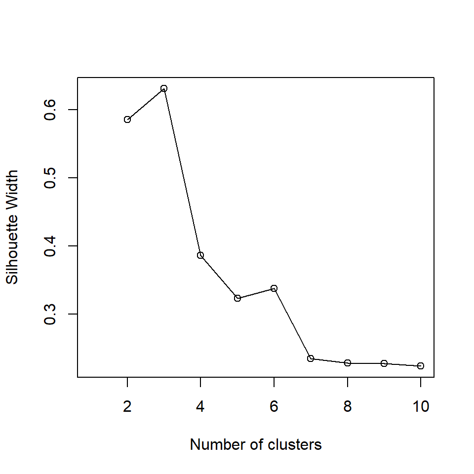

```r
plot(1:10, sil,
xlab = "Number of clusters",
ylab = "Silhouette Width")
lines(1:10, sil)
```

Cluster Interpretation:via Descriptive Statistics

```r
pam_fit <- pam(gower_dist, diss = TRUE, k = 3)
# add cluster labels to the data. We will use result1 later
college_clean <- data.frame(college_clean, pam_fit$cluster)
# show clustering results by college
result1 <- college_clean %>% dplyr::select(name,pam_fit.cluster)
# View(result1)
```

group_by cluster and then compute the summary data (means, median, etc) for each cluster

```r
pam_results <- college_clean %>%
  dplyr::select(-name) %>%
  mutate(cluster = pam_fit$clustering) %>% #add the cluster column
  group_by(cluster) %>% #group universities by its cluster
  do(the_summary = summary(.)) #do: summarize by group/cluster,add the_summary column

pam_results$the_summary
```

```
## [[1]]
##   accept_rate        Outstate         Enroll         Grad.Rate
##  Min.   :0.3283   Min.   : 2340   Min.   :  35.0   Min.   : 15.00
##  1st Qu.:0.7225   1st Qu.: 8842   1st Qu.: 194.8   1st Qu.: 56.00
##  Median :0.8004   Median :10905   Median : 308.0   Median : 67.50
##  Mean   :0.7820   Mean   :11200   Mean   : 418.6   Mean   : 66.97
##  3rd Qu.:0.8581   3rd Qu.:13240   3rd Qu.: 484.8   3rd Qu.: 78.25
##  Max.   :1.0000   Max.   :21700   Max.   :4615.0   Max.   :118.00
##  Private        isElite    pam_fit.cluster    cluster
##  No :  0   Not Elite:500   Min.   :1       Min.   :1
##  Yes:500   Elite    :  0   1st Qu.:1       1st Qu.:1
##                            Median :1       Median :1
##                            Mean   :1       Mean   :1
##                            3rd Qu.:1       3rd Qu.:1
##                            Max.   :1       Max.   :1
##
## [[2]]
##   accept_rate        Outstate         Enroll         Grad.Rate
##  Min.   :0.1545   Min.   : 5224   Min.   : 137.0   Min.   : 54.00
##  1st Qu.:0.4135   1st Qu.:13850   1st Qu.: 391.0   1st Qu.: 77.00
##  Median :0.5329   Median :17238   Median : 601.0   Median : 89.00
##  Mean   :0.5392   Mean   :16225   Mean   : 882.5   Mean   : 84.78
##  3rd Qu.:0.6988   3rd Qu.:18590   3rd Qu.:1191.0   3rd Qu.: 94.00
##  Max.   :0.9605   Max.   :20100   Max.   :4893.0   Max.   :100.00
##  Private       isElite   pam_fit.cluster    cluster
##  No : 4   Not Elite: 0   Min.   :2       Min.   :2
##  Yes:65   Elite    :69   1st Qu.:2       1st Qu.:2
##                          Median :2       Median :2
##                          Mean   :2       Mean   :2
##                          3rd Qu.:2       3rd Qu.:2
##                          Max.   :2       Max.   :2
##
## [[3]]
##   accept_rate        Outstate         Enroll       Grad.Rate
##  Min.   :0.3746   Min.   : 2580   Min.   : 153   Min.   : 10.00
##  1st Qu.:0.6423   1st Qu.: 5295   1st Qu.: 694   1st Qu.: 46.00
##  Median :0.7458   Median : 6598   Median :1302   Median : 54.50
##  Mean   :0.7315   Mean   : 6698   Mean   :1615   Mean   : 55.42
##  3rd Qu.:0.8368   3rd Qu.: 7748   3rd Qu.:2184   3rd Qu.: 65.00
##  Max.   :1.0000   Max.   :15516   Max.   :6392   Max.   :100.00
##  Private        isElite    pam_fit.cluster    cluster
##  No :208   Not Elite:199   Min.   :3       Min.   :3
##  Yes:  0   Elite    :  9   1st Qu.:3       1st Qu.:3
##                            Median :3       Median :3
##                            Mean   :3       Mean   :3
##                            3rd Qu.:3       3rd Qu.:3
##                            Max.   :3       Max.   :3
```

The results suggest Cluster 1, is mainly Private/Not Elite with medium levels of out of state tuition and smaller levels of enrollment. Cluster 2, is mainly Private/Elite with lower levels of acceptance rates, high levels of out of state tuition, and high graduation rat Cluster 3, is mainly Public/Not Elite with the lowest levels of tuition, largest levels of enrollment, and lowest graduation rate.

Output medoids: representative university in each cluster:

```r
college_clean[pam_fit$medoids, ]
```

```
##                              name accept_rate Outstate Enroll Grad.Rate
## 492         Saint Francis College   0.7877629    10880    284        69
## 38                Barnard College   0.5616987    17926    531        91
## 234 Grand Valley State University   0.7525653     6108   1561        57
##     Private   isElite pam_fit.cluster
## 492     Yes Not Elite               1
## 38      Yes     Elite               2
## 234      No Not Elite               3
```

## Cluster Interpretation: via visualization

One way to visualize many variables in a lower dimensional space is with t-distributed stochastic neighborhood embedding, or t-SNE. This method is a dimension reduction technique that tries to preserve local structure so as to make clusters visible in a 2D or 3D visualization. it is a powerful but also sometimes puzzling technique, more see https://distill.pub/2016/misread-tsne/

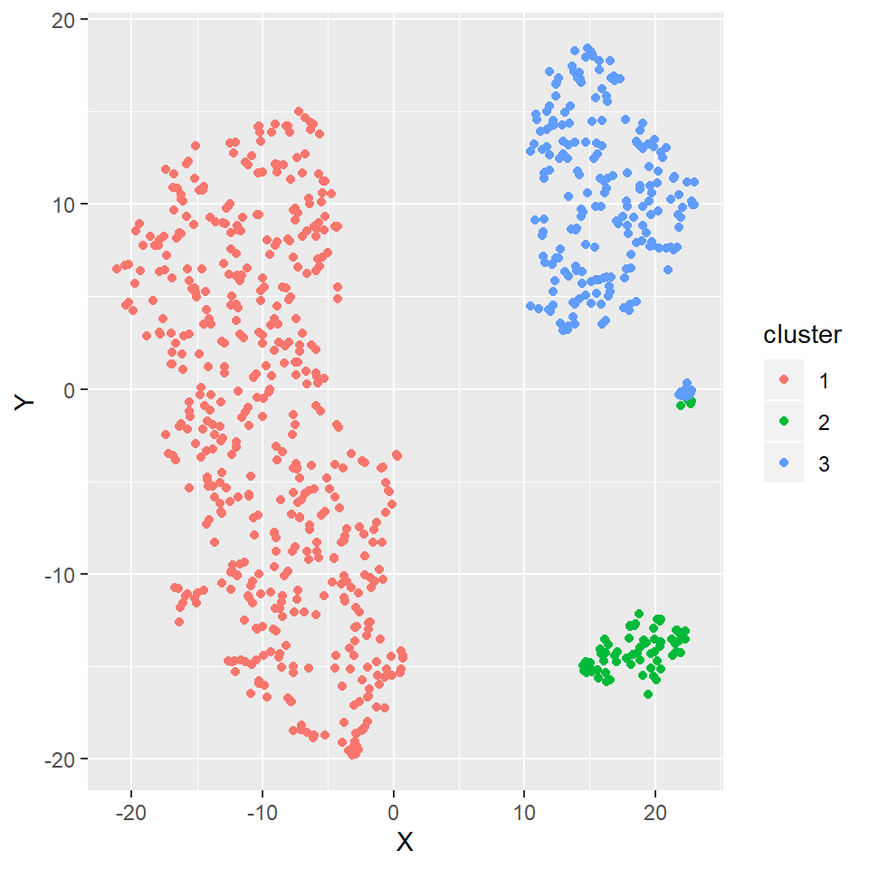

```r
tsne_obj <- Rtsne(gower_dist, is_distance = TRUE)

tsne_data <- tsne_obj$Y %>%
  data.frame() %>%
  setNames(c("X", "Y")) %>%
  mutate(cluster = factor(pam_fit$clustering),
         name = college_clean$name)

ggplot(aes(x = X, y = Y), data = tsne_data) +
  geom_point(aes(color = cluster))
```

What is in the little cluster between glue and green?

```r
tsne_data %>%
  filter(X > -15 & X < -10, Y > -20 & Y < -15) %>%
  left_join(college_clean, by = "name") %>%
  collect %>%
  .[["name"]]
```

```
## [1] "Marietta College"       "Providence College"
## [3] "Santa Clara University" "University of Richmond"
```

## cluster the same data set using kmeans

different implementations of kmeans are provided throught the algorithm argument to kmeans() method: “Hartigan-Wong”, “Lloyd”, “Forgy”, “MacQueen”. The default H-W implementation works well in most cases.  
To know more about the differences see https://core.ac.uk/download/pdf/27210461.pdf kmeans() take numeric data,

```r
college_clean_n <- College %>%
  mutate(name = row.names(.),
         accept_rate = Accept/Apps) %>%
  select(name,
         accept_rate,
         Outstate,
         Enroll,
         Grad.Rate,
         Private,
         Top10perc)

# turn 'yes' 'no' to 1 and 0
college_clean_n$Private<-as.integer(college_clean_n$Private)-1L
# z-score transformation to scale the variables. Scaling is needed because we will use euclidean distant
college_clean_n <- college_clean_n %>% mutate_at(scale, .vars=vars(-name))
college_clean_n %>% head()
```

```
##                           name accept_rate   Outstate      Enroll
## 1 Abilene Christian University -0.03235150 -0.7458755 -0.06346802
## 2           Adelphi University  0.90560931  0.4572019 -0.28839845
## 3               Adrian College  0.14465675  0.2011751 -0.47781355
## 4          Agnes Scott College  0.61183107  0.6262293 -0.69198176
## 5    Alaska Pacific University  0.06491314 -0.7160471 -0.78023197
## 6            Albertson College  0.46964025  0.7604569 -0.66938109
##    Grad.Rate   Private  Top10perc
## 1 -0.3180471 0.6121587 -0.2584163
## 2 -0.5509070 0.6121587 -0.6552335
## 3 -0.6673369 0.6121587 -0.3151045
## 4 -0.3762621 0.6121587  1.8390460
## 5 -2.9377211 0.6121587 -0.6552335
## 6 -0.6091220 0.6121587  0.5919062
```

get distance matrix, excluding first column: name

note: nstart is the parameter that allows the user to try multiple sets of initial centroids. You should use a nstart > 1, for example, nstart=25, this will run kmeans nstart number of times, each time with a different set of initial centroids. kmeans will then select the one with the lowest within cluster variation.

```r
dist_mat <- dist(college_clean_n[, -1], method="euclidean")

avgS <- c() #initiate an empty vector

for(k in 2:10){
  kmeans_cl <- kmeans(college_clean_n[,-1], centers=k, iter.max=500, nstart=1)
  s <- silhouette(kmeans_cl$cluster, dist_mat)
  avgS <- c(avgS, mean(s[,3])) # take the mean of sil_width of all observations, and save it in the avgS vector
}

data.frame(nClus=2:10, Silh=avgS)
```

```
##   nClus      Silh
## 1     2 0.3670936
## 2     3 0.3664791
## 3     4 0.2632232
## 4     5 0.2754929
## 5     6 0.2469106
## 6     7 0.2087288
## 7     8 0.2336098
## 8     9 0.2133607
## 9    10 0.2165633
```

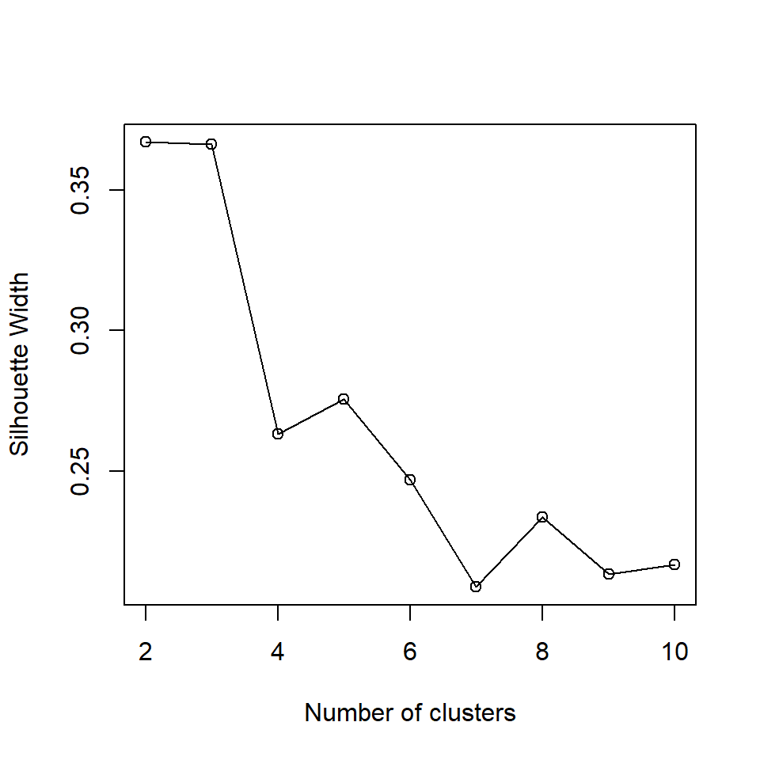

```r
plot(2:10, avgS,
  xlab = "Number of clusters",
  ylab = "Silhouette Width")
  lines(2:10, avgS)
```

2 clusters seem to be the best

```r
kmeans_fit <- kmeans(college_clean_n[,-1], 2)
```

get cluster means

```r
aggregate(college_clean_n[,-1],by=list(kmeans_fit$cluster),FUN=mean)
```

```
##   Group.1 accept_rate   Outstate     Enroll  Grad.Rate    Private
## 1       1 -0.12598787 -0.9288646  0.9439866 -0.5947042 -1.5895240
## 2       2  0.04788882  0.3530675 -0.3588155  0.2260510  0.6041885
##    Top10perc
## 1 -0.2843764
## 2  0.1080933
```

append cluster assignment to data

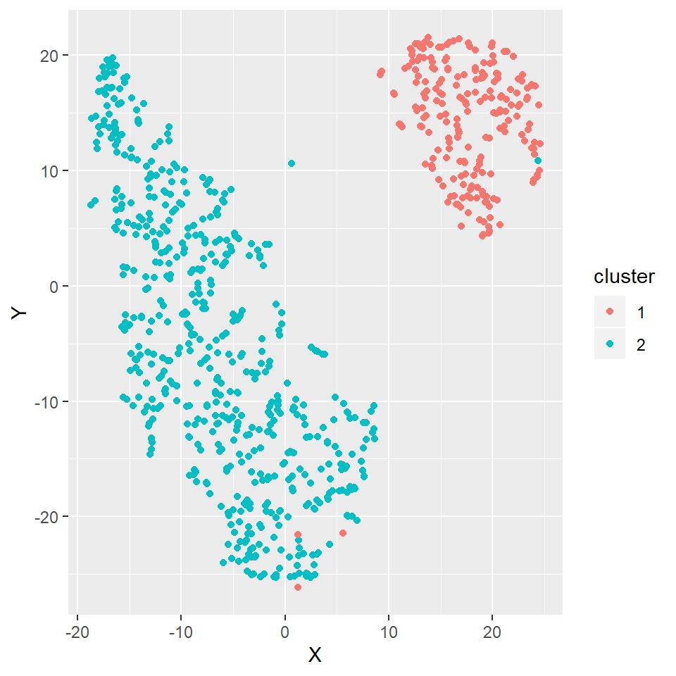

```r
college_clean_n <- data.frame(college_clean_n, kmeans_fit$cluster)
# Cluster Interpretation:via visualization
tsne_obj <- Rtsne(dist_mat, is_distance = TRUE)
tsne_data <- tsne_obj$Y %>%
data.frame() %>%
setNames(c("X", "Y")) %>%
mutate(cluster = factor(kmeans_fit$cluster),
name = college_clean_n$name)
ggplot(aes(x = X, y = Y), data = tsne_data) +
geom_point(aes(color = cluster))
```

TSNE is a powerful but sometimes puzzling technique More see https://distill.pub/2016/misread-tsne/ append cluster assignment to data

```r
college_clean_n <- data.frame(college_clean_n, kmeans_fit$cluster)
college_clean_n %>% head()
```

```
##                           name accept_rate   Outstate      Enroll
## 1 Abilene Christian University -0.03235150 -0.7458755 -0.06346802
## 2           Adelphi University  0.90560931  0.4572019 -0.28839845
## 3               Adrian College  0.14465675  0.2011751 -0.47781355
## 4          Agnes Scott College  0.61183107  0.6262293 -0.69198176
## 5    Alaska Pacific University  0.06491314 -0.7160471 -0.78023197
## 6            Albertson College  0.46964025  0.7604569 -0.66938109
##    Grad.Rate   Private  Top10perc kmeans_fit.cluster kmeans_fit.cluster.1
## 1 -0.3180471 0.6121587 -0.2584163                  2                    2
## 2 -0.5509070 0.6121587 -0.6552335                  2                    2
## 3 -0.6673369 0.6121587 -0.3151045                  2                    2
## 4 -0.3762621 0.6121587  1.8390460                  2                    2
## 5 -2.9377211 0.6121587 -0.6552335                  2                    2
## 6 -0.6091220 0.6121587  0.5919062                  2                    2
```

```r
result2 <- college_clean_n %>%
  dplyr::select(name,kmeans_fit.cluster)

View(result2)

result2.copy <- result2

result2$kmeans_fit.cluster[result2$kmeans_fit.cluster==2] <- 0
result2$kmeans_fit.cluster[result2$kmeans_fit.cluster==1] <- 2
result2$kmeans_fit.cluster[result2$kmeans_fit.cluster==0] <- 1
```

```r
table(result1$pam_fit.cluster, result2$kmeans_fit.cluster)
```

```
##
##       1   2
##   1 496   4
##   2  66   3
##   3   1 207
```

## build a hierarchical cluster using College data

method argument takes the agglomeration method to be used. This should be (an unambiguous abbreviation of) one of “ward.D”, “ward.D2”, “single”, “complete”, “average” (= UPGMA), “mcquitty” (= WPGMA), “median” (= WPGMC) or “centroid” (= UPGMC).

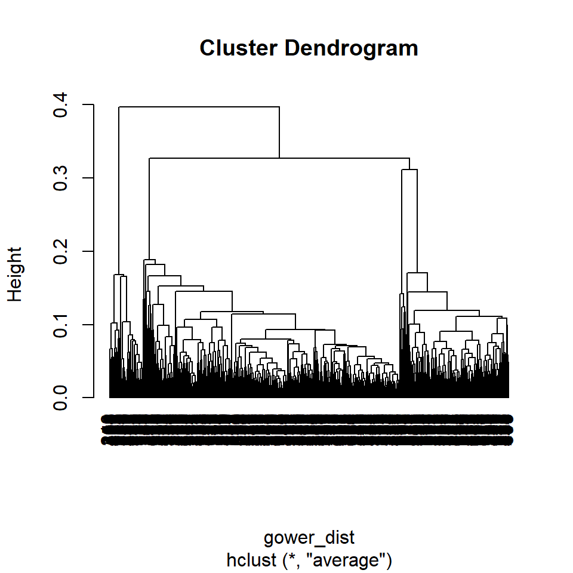

```r
h <- hclust(gower_dist, method="average")
# plot the dendrogram #hang decides where to start labels on axis. -0.1 is negative, so the x-axis labels will hang down from 0
plot(h, hang=-0.1)
```

If we want three clusters

```r
clus3 <- cutree(h, 3)
```

clus3 is a vector with the number of the cluster to which each observation was assigned. Observations keep the original order as in the dissimilar matrix.

```r
# clus3
clus3[492]
```

```
## [1] 1
```

```r
clus3[38]
```

```
## [1] 2
```

```r
clus3[234]
```

```
## [1] 3
```

492 is the index medoid for the 1st cluster, 38 is the index of the medoid for the 2nd/3rd clusters using PAM

compare with pam 3-cluter results (we verified that the cluster labels 1, 2, 3 match PAM’s mediods result)

```r
table(result1$pam_fit.cluster, clus3)
```

```
##    clus3
##       1   2   3
##   1 500   0   0
##   2   0  65   4
##   3   0   0 208
```

## use DIANA in the cluster package for divisive hierarchical clustering

because we provided a dissimilarity matrix, we don’t need to supply other arguments to this function. dissimilarity matrix incoporated the distance measures and data normalization

```r
d <- diana(gower_dist)
d3 <- cutree(d, 3)
table(result1$pam_fit.cluster, d3) #(we verified that the cluster labels 1, 2, 3 match PAM mediods result)
```

```
##    d3
##       1   2   3
##   1 500   0   0
##   2   0  69   0
##   3   0   9 199
```

492 is the index medoid for the 1st cluster, 38 is the index of the medoid for the 2nd/3rd clusters using PAM we see the results are very close.

Because we are using the same dissimilarity matrix for PAM and hierarchical clusterings, it is not too suprising that their results are very close, but still a way to validate PAM results.

Verifing kmean results using this method is doable but a bit more difficult, because there is no medoids for an easy mapping of cluster numbers between two methods

[REQUIRED]

1. Students: run Kmean or PAM on your dataset (run it multiple times without setting set.seed()). Report differences in performance between runs (Silhouette width or overlaps of observations in different clustering). Can you make sense of the clusters produced?
2. Run a hierarchical method on your dataset, try a couple of different cuts. Are these results more meaningful than those from the participation method?

```r
library(dbscan)
library(dplyr) # for data cleaning
library(ISLR) # for college dataset
# The package dbscan provides high performance code for DBSCAN and OPTICS
```

use simulated data to show the use of dbscan

```r
set.seed(2)
n <- 400

# generate four slightly overlapping Gaussians in 2-D space with 100 points each.

x <- cbind(
   #points (x,y): random normally distributed data adding uniform distribution noices (runif)
   #runif(4, 0, 1) generate 4 uniform distributed data values in [0, 1]
   x = runif(4, 0, 1) + rnorm(n, sd = 0.1),
   y = runif(4, 0, 1) + rnorm(n, sd = 0.1)
   )
```

cluster labels

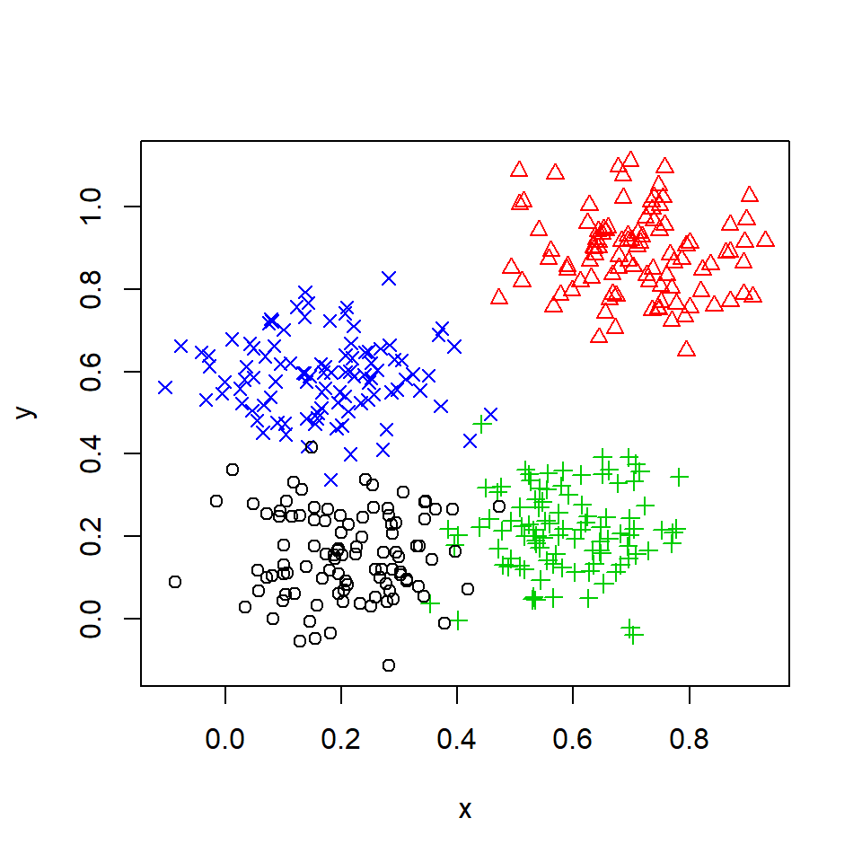

```r
true_clusters <- rep(1:4, time = 100)
# take a look at the data, 4 colors and symbols to indicate true clusters for the points
plot(x, col = true_clusters, pch = true_clusters) #col: color, pch:symbols
```

next, we need to decide on minPts and eps. The rule of thumb fo minPts = # of dimensions of the dataset + 1, this is 3 in our case eps can be determined by plotting the points’ kNN distances (ie. the distance to the kth nearest neighbor) in increasing order and look for a knee in the plot. distance of each data point to its 3 nearest neighbor is plotted (3x400 =1200 distances)

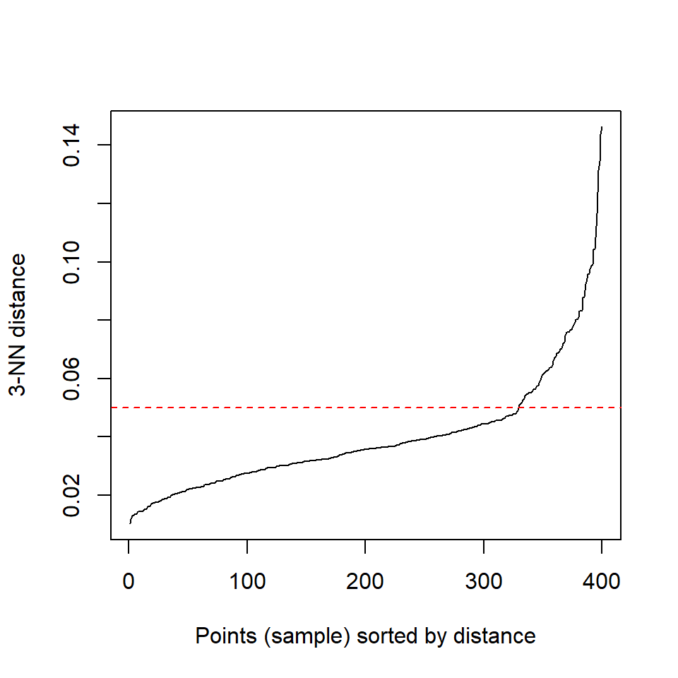

```r
kNNdistplot(x, k=3)
# distance 0.05 is the "knee", adding a reference line to show this
abline(h=0.05, col ="red", lty=2)
```

now perform DBSCAN

```r
res <- dbscan(x, eps=0.05, minPts=3)
# points with cluster id = 0 are noise.
res
```

```
## DBSCAN clustering for 400 objects.
## Parameters: eps = 0.05, minPts = 3
## The clustering contains 6 cluster(s) and 30 noise points.
##
##   0   1   2   3   4   5   6
##  30 185  87  89   3   3   3
##
## Available fields: cluster, eps, minPts
```

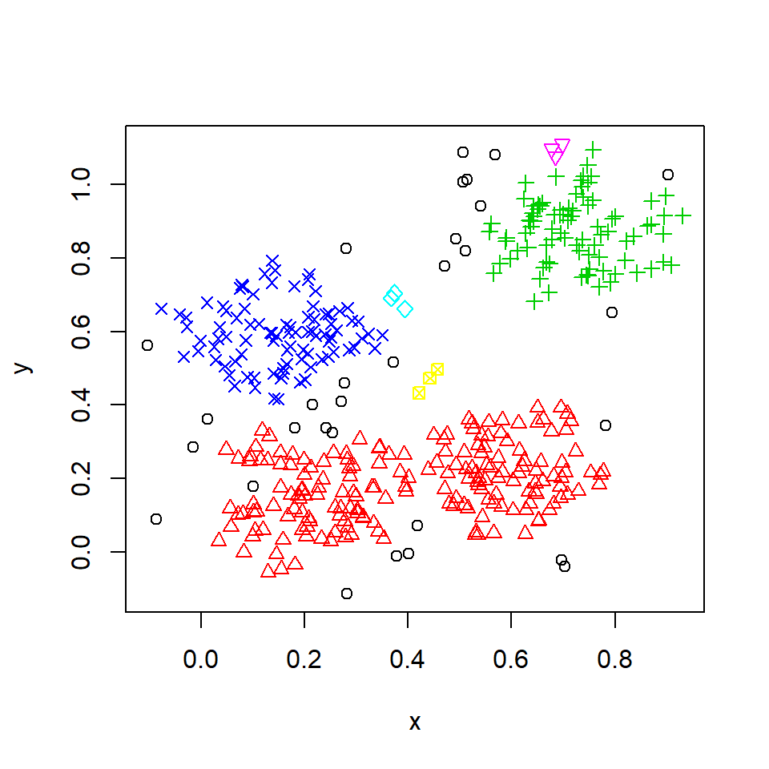

```r
# dbscan alsp provide a plot that adds convect cluster hulls to the scatter plot.
plot(x, col=res$cluster+1L, pch=res$cluster+1L)
```

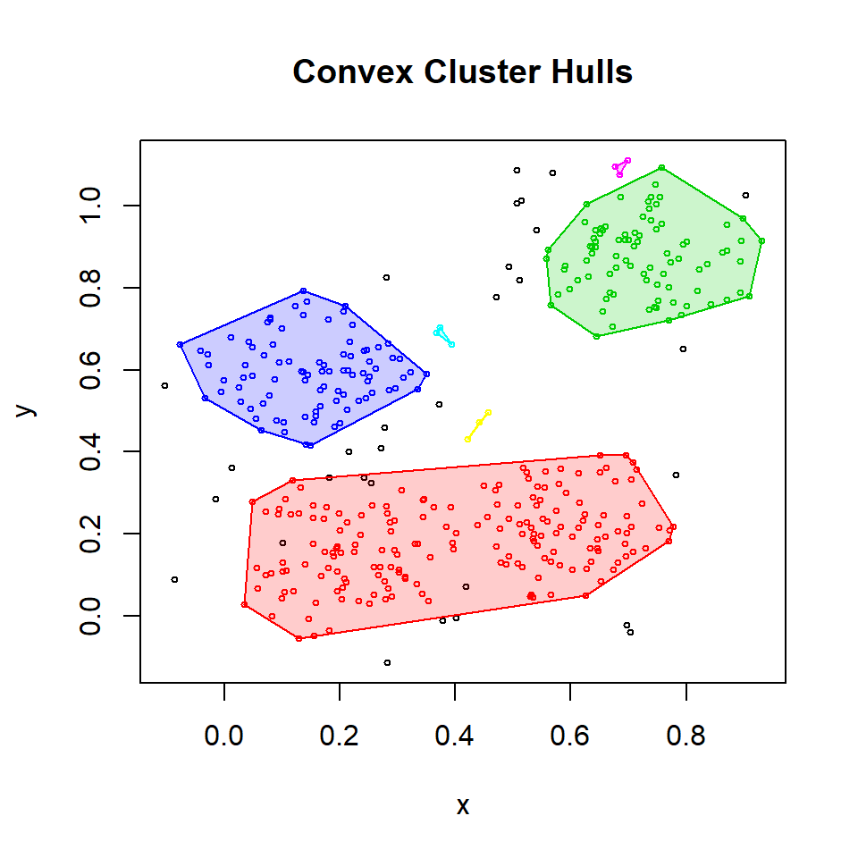

```r
hullplot(x, res)
```

to see the cluster assignment of the original data points

```r
predict(res, x[1:25,], data=x) #the first 25 data points
```

```
##  [1] 1 2 1 0 1 2 1 3 1 2 1 3 1 0 1 3 1 2 0 3 1 2 1 3 1
```

```r
predict(res, x, data=x)
```

```
##   [1] 1 2 1 0 1 2 1 3 1 2 1 3 1 0 1 3 1 2 0 3 1 2 1 3 1 2 1 3 1 2 1 3 1 2 1
##  [36] 3 1 2 1 3 0 2 1 4 1 2 1 3 1 2 1 3 1 0 1 3 1 2 1 0 1 2 1 3 0 2 1 3 1 2
##  [71] 1 3 1 2 0 3 1 2 1 3 1 2 1 3 1 2 1 3 1 2 1 3 1 2 1 3 1 2 1 3 1 2 1 4 1
## [106] 0 1 3 1 5 1 3 0 2 1 3 1 2 1 3 1 2 1 3 1 2 0 3 0 2 1 3 1 2 1 3 1 2 1 3
## [141] 1 2 1 3 1 2 1 3 1 2 1 3 1 0 1 3 1 2 1 3 1 2 6 3 1 0 1 3 1 2 1 3 1 2 1
## [176] 3 1 0 1 3 1 2 1 3 1 2 1 3 1 2 1 3 1 2 1 3 1 2 1 3 1 2 1 3 1 2 1 3 1 2
## [211] 1 3 1 2 1 3 1 2 1 3 1 2 1 0 1 2 1 4 1 0 1 3 0 2 1 3 1 2 1 6 1 2 1 3 1
## [246] 2 1 3 1 2 1 3 1 2 1 3 1 5 1 3 1 0 1 3 0 2 1 3 0 5 1 3 1 2 1 0 1 2 1 3
## [281] 1 2 1 3 1 2 1 3 1 2 1 3 1 2 1 3 1 2 1 3 1 0 1 3 1 2 0 3 1 2 1 3 1 2 1
## [316] 3 1 2 1 0 1 2 1 3 0 2 1 3 1 2 1 3 1 2 1 3 1 2 1 3 1 2 1 3 1 2 1 3 1 2
## [351] 1 3 0 2 1 3 1 2 1 3 3 2 1 3 1 2 1 3 1 2 1 3 1 2 1 6 1 2 1 3 1 2 1 3 1
## [386] 2 1 3 1 2 1 3 1 2 1 0 1 0 1 0
```

Clustering with OPTICS To benefit from the flexibility of OPTICS algorithm, we select larger eps and minPts to run OPTICS minPts = 10 means the core-distance is defined as the distance to the 9th nearest neighbor

```r
res_op <- optics(x, eps=10, minPts = 10)
```

Some additional parameters you will see in the result: eps_cl: another threshold on eps may be used for identify final clusters, eps_cl<=eps xi: if use optics or hierarchical clustering, xi is the steepness threshold to identify clusters hierarchically using the reachability plot.

```r
res_op
```

```
## OPTICS ordering/clustering for 400 objects.
## Parameters: minPts = 10, eps = 10, eps_cl = NA, xi = NA
## Available fields: order, reachdist, coredist, predecessor, minPts,
##                   eps, eps_cl, xi
```

to get the computed order of the points The order says that data point 1 in the data set is the first in the order, data point 363 is the second and so forth

```r
head(res_op$order, n= 50)
```

```
##  [1]   1 363 209 349 337 301 357 333 321 285 281 253 241 177 153  57 257
## [18]  29  77 169 105 293 229 145 181 385 393 377 317 381 185 117 101   9
## [35]  73 237 397 369 365 273 305 245 249 309 157 345 213 205  97  49
```

This density-based order produced by OPTICS can be directly used to plot a reachability plot 4 Valleys represent potential clusters separated by peaks. Very high peaks may indicate noise points.

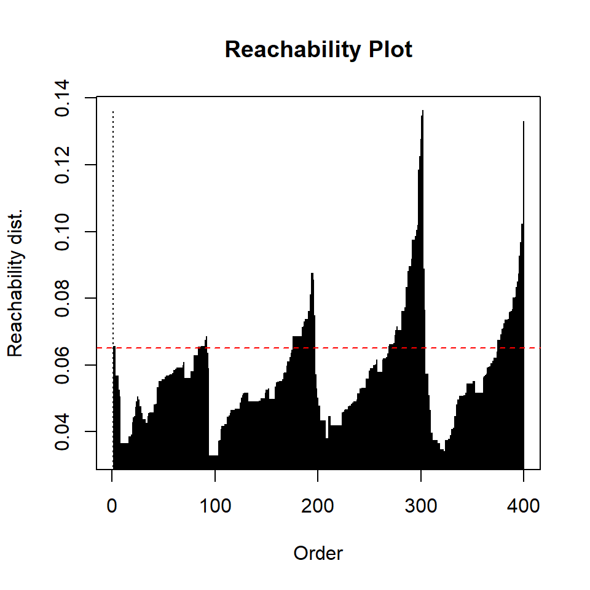

```r
plot(res_op)
abline(h=0.065, col ="red", lty=2) #add a reference cutting line (lty=2 draws a dashed line) for extracting the clusters later
```

We can also visualize the order on the original datasets by plotting a ploygon on top of the original data points using the order if you run a smaller example, combining the order information with the graph, you will be able see clearly the order of the visit of the points in the dataset.

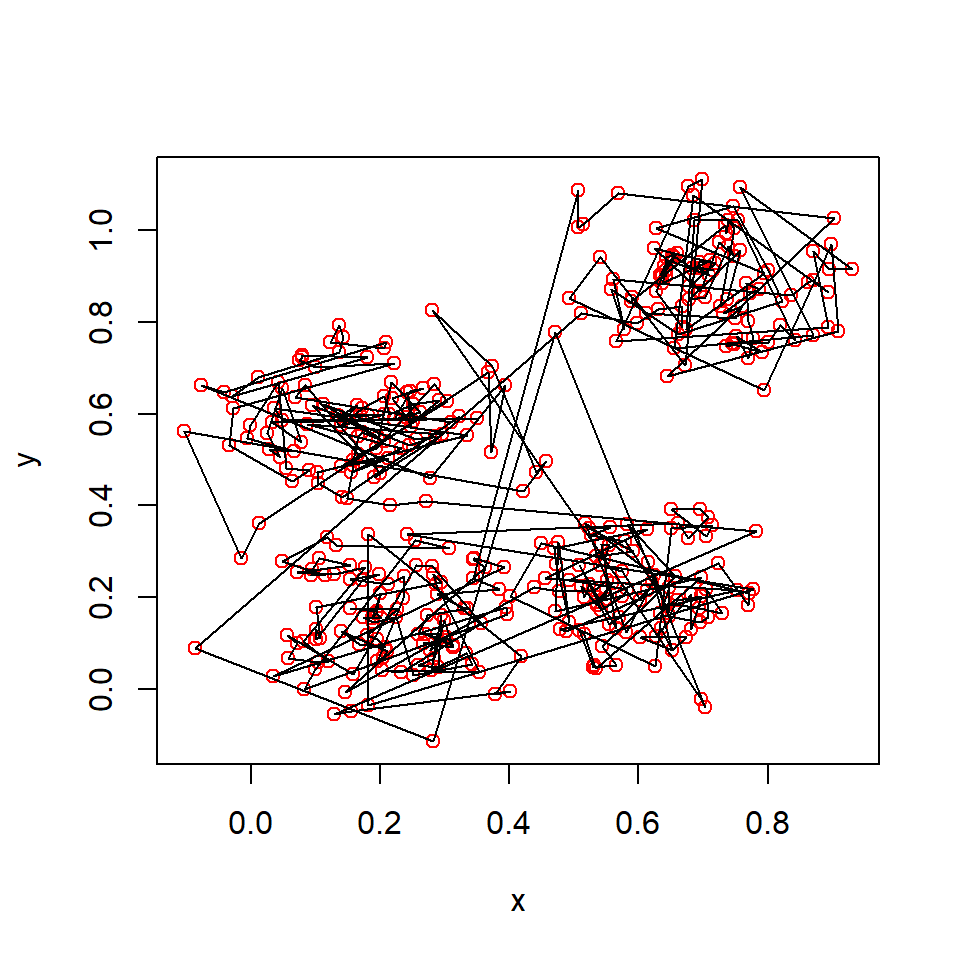

```r
plot(x, col="red")
polygon(x[res_op$order,])
```

Now we can extract a DBSCAN-type clustering based on the reachability plot Because this method extracts clusters like DBSCAN,it cannot identify partitions that exhibit very significant differences in density As shown above, eps_cl=0.065 will result in 4 clusters

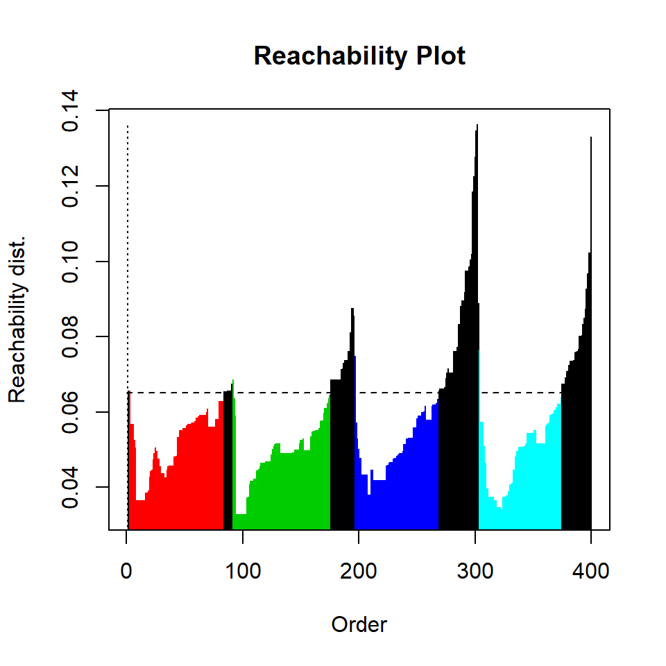

```r
res_op_c <- extractDBSCAN(res_op, eps_cl=0.065)
plot(res_op_c)
```

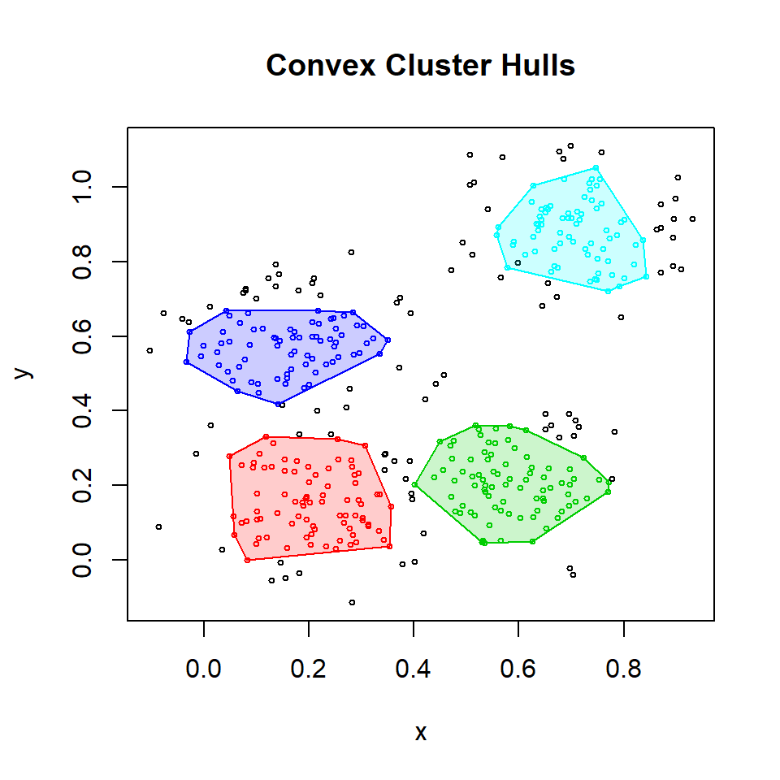

```r
hullplot(x, res_op_c)
```

```r
res_op_c #we can see 92 points were not included in the clusters
```

```
## OPTICS ordering/clustering for 400 objects.
## Parameters: minPts = 10, eps = 10, eps_cl = 0.065, xi = NA
## The clustering contains 4 cluster(s) and 92 noise points.
##
##  0  1  2  3  4
## 92 81 84 72 71
##
## Available fields: order, reachdist, coredist, predecessor, minPts,
##                   eps, eps_cl, xi, cluster
```

this can be a reliable way to identify tight clusters in a dataset and tight clusters can be used a summary of the daaset.

We can also extract a hierarchical cluster structure using extract Xi xi is the steepness threshold, describes the relative magnitude of the change of cluster density (i.e., reachability) Significant changes in relative reachability allow for clusters to manifest themselves hierarchically as ‘dents’ in the ordering structure. The hierarchical representation ExtractXi can, as opposed to the ExtractDBSCAN method, produce clusters of varying densities. Clusters are represented as contiguous ranges in the reachability plot and are available in the field clusters_xi

```r
(res_op_h <- extractXi(res_op, xi=0.05))
```

```
## OPTICS ordering/clustering for 400 objects.
## Parameters: minPts = 10, eps = 10, eps_cl = NA, xi = 0.05
## The clustering contains 7 cluster(s) and 1 noise points.
##
## Available fields: order, reachdist, coredist, predecessor, minPts,
##                   eps, eps_cl, xi, clusters_xi, cluster
```

```r
res_op_h$clusters_xi
```

```
##   start end cluster_id
## 1     1 194          1
## 2     1 301          2
## 3     8  23          3
## 4    94 106          4
## 5   196 288          5
## 6   302 399          6
## 7   308 335          7
```

We can visualize the clusters in the reachability plot clusters represented using colors and vertical bars below the plot.

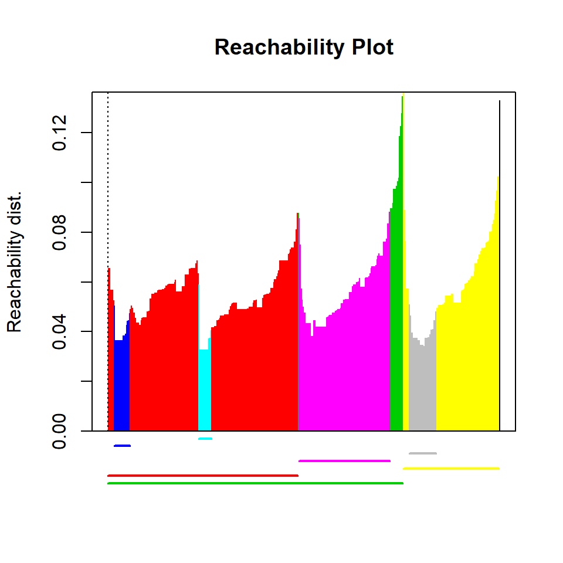

```r
plot(res_op_h)
```

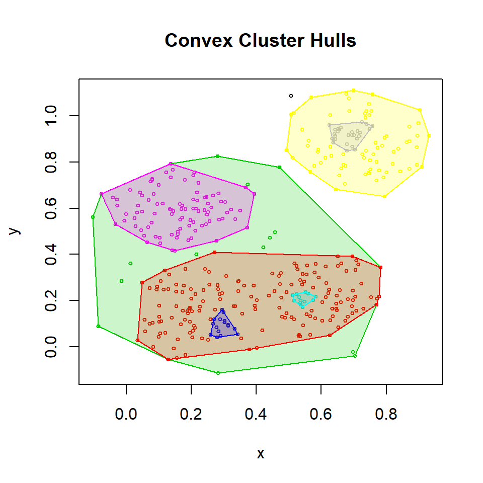

```r
hullplot(x, res_op_h)
```

To represent the hierarchical clustering as a dendrogram

```r
(dend <- as.dendrogram(res_op_h))
```

```
## 'dendrogram' with 2 branches and 400 members total, at height 0.1363267
```

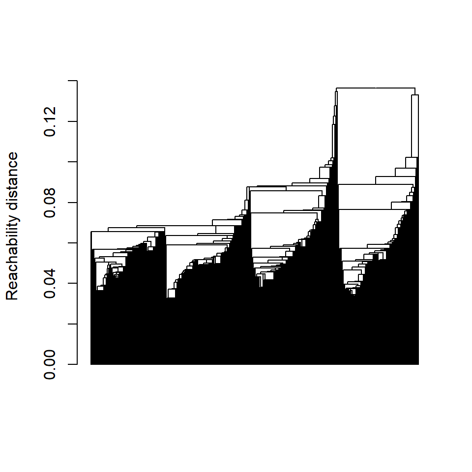

```r
plot(dend, ylab="Reachability distance", leaflab="none")
```

Run OPTICS on the College dataset, using gower_dist matrix

```r
set.seed(1680) # for reproducibility
data(College, package="ISLR")
college_clean <- College %>%
   mutate(name = row.names(.),
          accept_rate = Accept/Apps,
          isElite = cut(Top10perc,
                        breaks = c(0, 50, 100),
                        labels = c("Not Elite", "Elite"),
                        include.lowest = TRUE)) %>%
   mutate(isElite = factor(isElite)) %>%
   select(name, accept_rate, Outstate, Enroll,
          Grad.Rate, Private, isElite)

gower_dist <- daisy(college_clean[, -1],
                     metric = "gower",
                     type = list(logratio = 3))

dim(college_clean)
```

```
## [1] 777   7
```

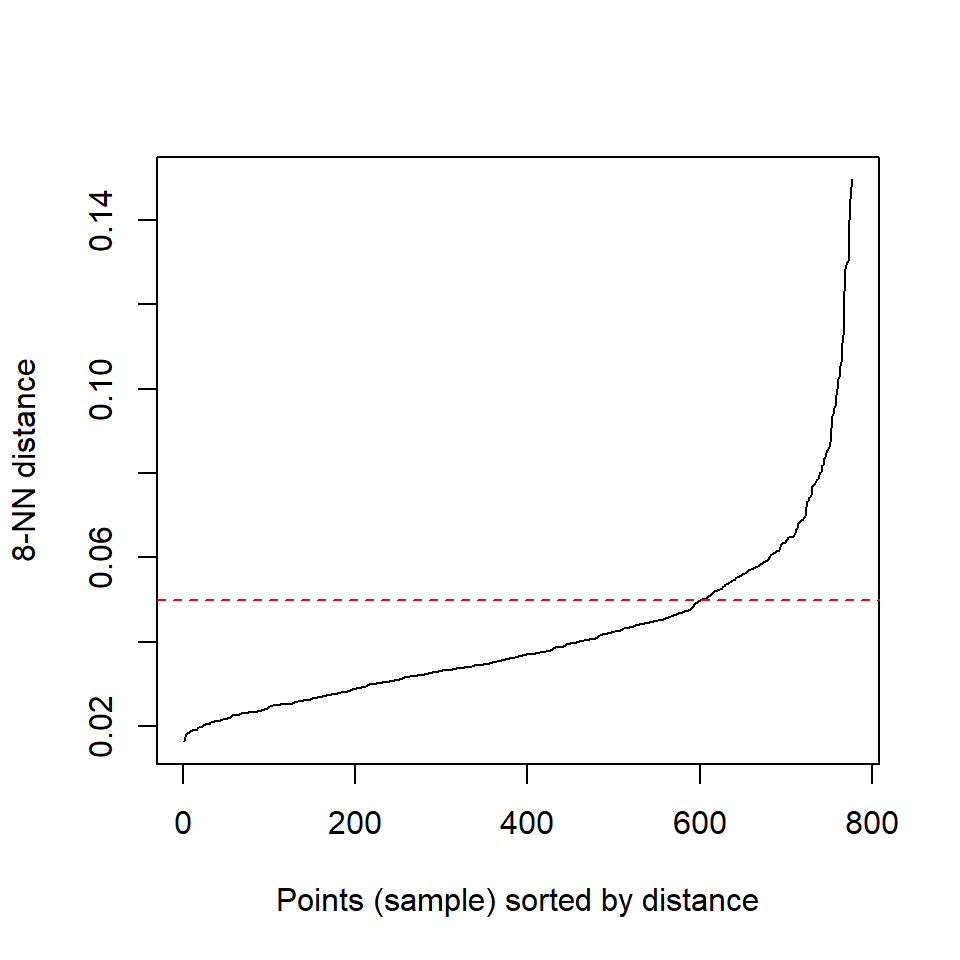

```r
# 7 dimensions, so set k = 8
kNNdistplot(gower_dist, k=8)
abline(h=0.05, col='red', lty=2)
```

```r
(res_col <- optics(gower_dist, eps=10, minPts = 10))
```

```
## OPTICS ordering/clustering for 777 objects.
## Parameters: minPts = 10, eps = 10, eps_cl = NA, xi = NA
## Available fields: order, reachdist, coredist, predecessor, minPts,
##                   eps, eps_cl, xi
```

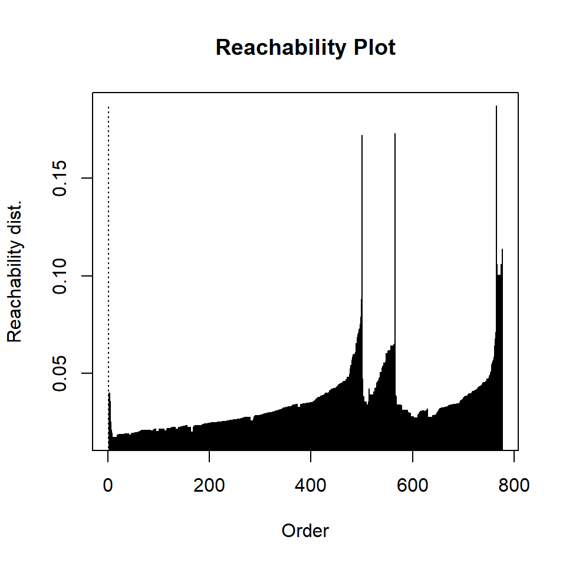

```r
plot(res_col)
```

```r
# 3 clusters, 78 noise points
(res_col_d <- extractDBSCAN(res_col, eps_cl=0.05))
```

```
## OPTICS ordering/clustering for 777 objects.
## Parameters: minPts = 10, eps = 10, eps_cl = 0.05, xi = NA
## The clustering contains 3 cluster(s) and 78 noise points.
##
##   0   1   2   3
##  78 476  35 188
##
## Available fields: order, reachdist, coredist, predecessor, minPts,
##                   eps, eps_cl, xi, cluster
```

```r
# 4 clusters, 2 noise points
(res_col_h <- extractXi(res_col, xi=0.05))
```

```
## OPTICS ordering/clustering for 777 objects.
## Parameters: minPts = 10, eps = 10, eps_cl = NA, xi = 0.05
## The clustering contains 4 cluster(s) and 2 noise points.
##
## Available fields: order, reachdist, coredist, predecessor, minPts,
##                   eps, eps_cl, xi, clusters_xi, cluster
```

```r
res_col_h$clusters_xi #cluster 4 is tiny, what is in there?
```

```
##   start end cluster_id
## 1     1 500          1
## 2   501 564          2
## 3   566 764          3
## 4   765 776          4
```

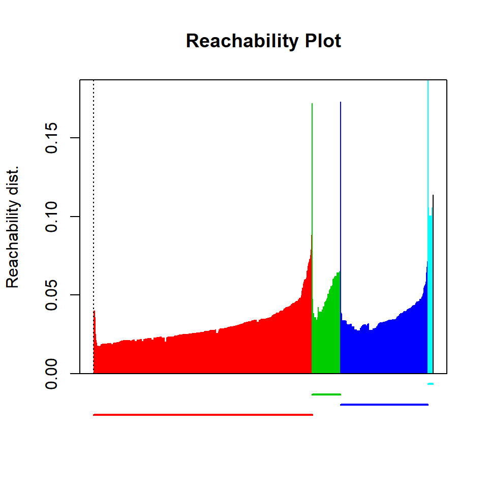

```r
plot(res_col_h)
```

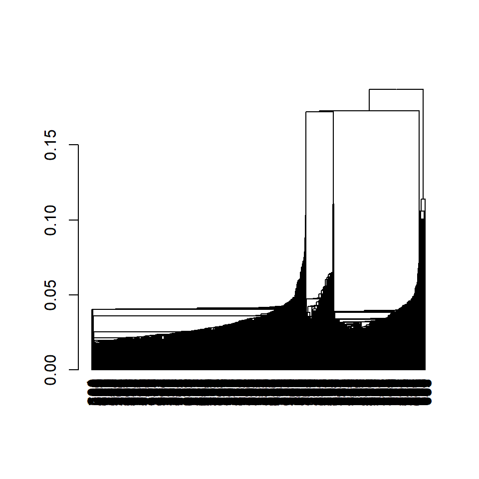

```r
dend_col <-as.dendrogram(res_col_h)
plot(dend_col)
```

```r
college_clean[res_col_h$order[765:776],]
```

```
##                                            name accept_rate Outstate
## 223             Georgia Institute of Technology   0.5776445     6489
## 652 University of North Carolina at Chapel Hill   0.4100438     8400
## 694                      University of Virginia   0.3397060    12212
## 624             University of Illinois - Urbana   0.7799719     7560
## 620                       University of Florida   0.7100040     7090
## 606        University of California at Berkeley   0.4152368    11648
## 592                       Trenton State College   0.4585482     5391
## 570                     SUNY College at Geneseo   0.5305885     6550
## 562                          SUNY at Binghamton   0.4263293     6550
## 139                 College of William and Mary   0.4364198    11720
## 640           University of Minnesota at Morris   0.5994513     9843
## 607          University of California at Irvine   0.6863932    12024
##     Enroll Grad.Rate Private isElite
## 223   2276        70      No   Elite
## 652   3331        83      No   Elite
## 694   2678        95      No   Elite
## 624   5705        81      No   Elite
## 620   3623        66      No   Elite
## 606   3215        78      No   Elite
## 592    944        81      No   Elite
## 570   1143        76      No   Elite
## 562   1757        80      No   Elite
## 139   1217        93      No   Elite
## 640    588        51      No   Elite
## 607   2478        66      No   Elite
```

```r
# which cluster is UMich at Ann Arbor?
college_clean[college_clean$name=="University of Michigan at Ann Arbor", ]
```

```
##                                    name accept_rate Outstate Enroll
## 638 University of Michigan at Ann Arbor   0.6756475    15732   4893
##     Grad.Rate Private isElite
## 638        87      No   Elite
```

```r
match(638, res_col_h$order)
```

```
## [1] 777
```

Michigan is 777 in the order, by checking res_col_h$clusters_xi, it is one of the two outliers by comparing the results from OPTICS with PAM and see they are similar, our confidence in the clusters identified increases.

[REQUIRED] 1. Apply BDSCAN and OPTICS on your dataset, could you identified some good clusters?